# stat3914_lab_2

SID 460375939

6 September 2018

## Data cleaning

Checking the data for any NA entries.

```r
dat_na = is.na(dat)
which(dat_na)
```

```
## integer(0)
```

```r
summary(dat)
```

```
##     pregnant         glucose         pressure         triceps
##  Min.   : 0.000   Min.   :  0.0   Min.   :  0.00   Min.   : 0.00
##  1st Qu.: 1.000   1st Qu.: 99.0   1st Qu.: 62.00   1st Qu.: 0.00
##  Median : 3.000   Median :117.0   Median : 72.00   Median :23.00
##  Mean   : 3.845   Mean   :120.9   Mean   : 69.11   Mean   :20.54
##  3rd Qu.: 6.000   3rd Qu.:140.2   3rd Qu.: 80.00   3rd Qu.:32.00
##  Max.   :17.000   Max.   :199.0   Max.   :122.00   Max.   :99.00
##     insulin           mass          pedigree           age
##  Min.   :  0.0   Min.   : 0.00   Min.   :0.0780   Min.   :21.00
##  1st Qu.:  0.0   1st Qu.:27.30   1st Qu.:0.2437   1st Qu.:24.00
##  Median : 30.5   Median :32.00   Median :0.3725   Median :29.00
##  Mean   : 79.8   Mean   :31.99   Mean   :0.4719   Mean   :33.24
##  3rd Qu.:127.2   3rd Qu.:36.60   3rd Qu.:0.6262   3rd Qu.:41.00
##  Max.   :846.0   Max.   :67.10   Max.   :2.4200   Max.   :81.00
##  diabetes
##  neg:500
##  pos:268
##
##
##
##
```

From the output, we see that there is no missing data. However, we can see that there are a lot of zero entries where it does not make sense, such as 0’s in glucose, blood pressure, triceps and BMI. So we’ll remove the rows with these 0 values.

```
## [1] 532   9
```

```r
dat_clean$diabetes = as.character(dat_clean$diabetes)
for(i in 1:532) {
  if(dat_clean[i,9] == "pos") {
    dat_clean[i,9] <- 1
  } else {
    dat_clean[i,9] <- 0
  }
}
dat_clean$diabetes = as.numeric(dat_clean$diabetes)
str(dat_clean)
```

```
## 'data.frame':    532 obs. of  9 variables:
##  $ pregnant: int  6 1 1 0 3 2 1 5 0 1 ...
##  $ glucose : int  148 85 89 137 78 197 189 166 118 103 ...
##  $ pressure: int  72 66 66 40 50 70 60 72 84 30 ...
##  $ triceps : int  35 29 23 35 32 45 23 19 47 38 ...
##  $ insulin : int  0 0 94 168 88 543 846 175 230 83 ...
##  $ mass    : num  33.6 26.6 28.1 43.1 31 30.5 30.1 25.8 45.8 43.3 ...
##  $ pedigree: num  0.627 0.351 0.167 2.288 0.248 ...
##  $ age     : int  50 31 21 33 26 53 59 51 31 33 ...
##  $ diabetes: num  1 0 0 1 1 1 1 1 1 0 ...
```

```r
attach(dat_clean)
y = dat_clean$diabetes
X = dat_clean[,c(1:8)]
X2 = model.matrix(~-1+pregnant +glucose +pressure  + triceps +insulin +mass +pedigree + age ,data=dat_clean)
dat.clean = data.frame(y,X)
```

## Building the classifiers

Loading the functions from cvTools into memory, as such,

## K - Nearest Neighbours

Set the range of values for K which we will use for knn.

```r
k.values = seq(1,30)
```

Perform 10-fold ($V=10$) cross-validation

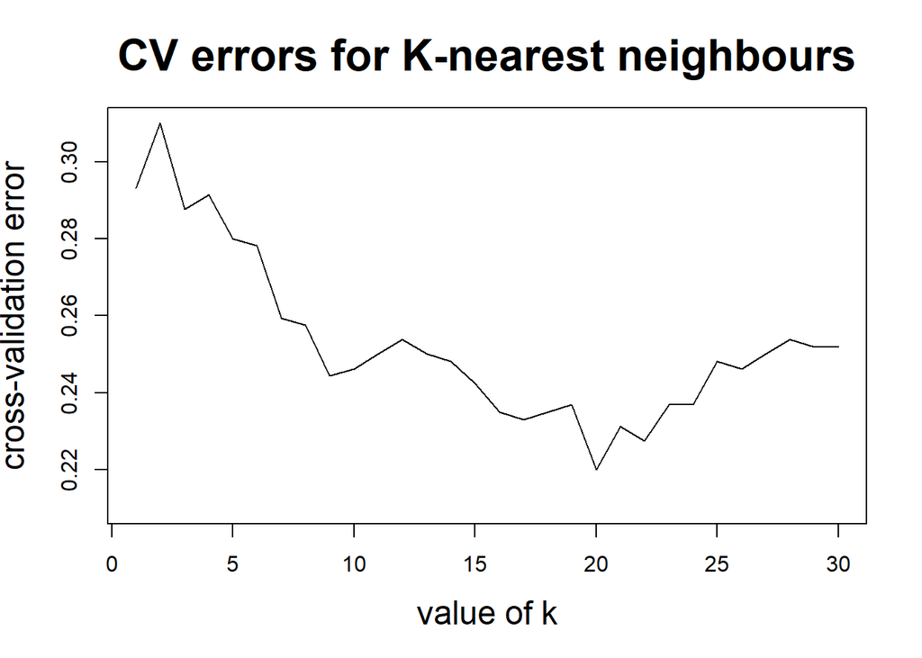

```r
V = 10

# Loop through all values of k and calculate the cross-validation error
cv.errors = c()
for (i in 1:length(k.values)) {
  cv.errors[i] = cv.knn(X,as.factor(y),k=k.values[i],V,seed=1)
}
plot(k.values,cv.errors,type="l",xlab="value of k",ylab="cross-validation error",cex.lab=1.5,
    main="CV errors for K-nearest neighbours",cex.main=2,ylim=c(0.21,0.31))
```

```r
k.values[which.min(cv.errors)]
```

```
## [1] 20
```

```r
min(cv.errors)
```

```
## [1] 0.2199248
```

# Linear and Quadratic discriminant analysis

Load the libraries with the LDA/QDA methods.

Fit the LDA method.

```r
res <- lda(y~., data=X,subset=1:length(y))
res
```

```
## Call:
## lda(y ~ ., data = X, subset = 1:length(y))
##
## Prior probabilities of groups:
##         0         1
## 0.6672932 0.3327068
##
## Group means:
##   pregnant  glucose pressure  triceps   insulin     mass  pedigree
## 0 2.926761 110.0169 69.91268 27.29014  96.57465 31.42958 0.4463155
## 1 4.700565 143.1186 74.70056 32.97740 151.92090 35.81977 0.6165876
##        age
## 0 29.22254
## 1 36.41243
##
## Coefficients of linear discriminants:
##                    LD1
## pregnant  0.0880661730
## glucose   0.0280460408
## pressure -0.0048836245
## triceps   0.0023296215
## insulin  -0.0007072004
## mass      0.0544616696
## pedigree  0.8166748339
## age       0.0192557029
```

The above output suggests the following interpretations for each of the variables. The main interpretation is that you are more likely to get diabetes if you have more babies, have higher BMI, and if you are older. We now calculate the cross validation error for LDA.

```r
res.lda = cv.da(X,y,method="lda",V,seed=1)
res.lda
```

```
## [1] 0.2255639
```

The CV error for LDA is 22.6 percent which is worse than knn.

Next, we fit QDA.

```r
res <- qda(y~., data=X,subset=1:length(y))
res
```

```
## Call:
## qda(y ~ ., data = X, subset = 1:length(y))
##
## Prior probabilities of groups:
##         0         1
## 0.6672932 0.3327068
##
## Group means:
##   pregnant  glucose pressure  triceps   insulin     mass  pedigree
## 0 2.926761 110.0169 69.91268 27.29014  96.57465 31.42958 0.4463155
## 1 4.700565 143.1186 74.70056 32.97740 151.92090 35.81977 0.6165876
##        age
## 0 29.22254
## 1 36.41243
```

Intepretation is more diffucult, than for LDA, but the group means suggest identical intepretations as for LDA.

```r
res.qda = cv.da(X,y,method="qda",V,seed=1)
res.qda
```

```
## [1] 0.2443609
```

The CV error is for QDA 24.4% percent and is worse than LDA.

# Logistic regression

Fit a logistic regression model on the cleaned data.

```r
X = data.frame(X)

res.glm = glm(y~.,family=binomial,data=X)
summary(res.glm)
```

```
##
## Call:
## glm(formula = y ~ ., family = binomial, data = X)
##
## Deviance Residuals:
##     Min       1Q   Median       3Q      Max
## -2.8627  -0.6639  -0.3672   0.6347   2.4942
##
## Coefficients:
##              Estimate Std. Error z value Pr(>|z|)
## (Intercept) -9.677562   1.005400  -9.626  < 2e-16 ***
## pregnant     0.121235   0.043926   2.760 0.005780 **
## glucose      0.037439   0.004765   7.857 3.92e-15 ***
## pressure    -0.009316   0.010446  -0.892 0.372494
## triceps      0.006341   0.014853   0.427 0.669426
## insulin     -0.001053   0.001007  -1.046 0.295651
## mass         0.085992   0.023661   3.634 0.000279 ***
## pedigree     1.335764   0.365771   3.652 0.000260 ***
## age          0.026430   0.013962   1.893 0.058371 .
## ---
## Signif. codes:  0 '***' 0.001 '**' 0.01 '*' 0.05 '.' 0.1 ' ' 1
##
## (Dispersion parameter for binomial family taken to be 1)
##
##     Null deviance: 676.79  on 531  degrees of freedom
## Residual deviance: 465.23  on 523  degrees of freedom
## AIC: 483.23
##
## Number of Fisher Scoring iterations: 5
```

Load some code for corss validation of glms.

Calculate the CV error for glms.

```r
res.glm.cv = cv.glm(X,y,V,seed=1)
res.glm.cv
```

```
## [1] 0.2180451
```

The CV error for glms is 21.8 percent. This is currently our best classifier.

Calculate the CV error for glms using model selection via backward selection.

Calculate the CV error for glms using AIC and BIC

Calcualte the CV error for glms using backward selection usign AIC and BIC.

```
## [1] 0.2161654
```

```
## [1] 0.2180451
```

# CART

Load the CART functions in to R.

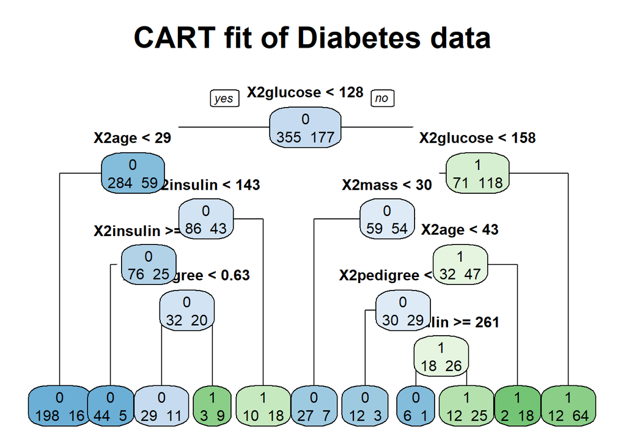

```r
library(rpart)

# Be careful as coding y as a factor here
# Otherwise R will do a regression tree
# Rather than a classification tree
res.rpart <- rpart(as.factor(y) ~ X2, data=dat.clean)

library(rpart.plot)
rpart.plot(res.rpart,type=1,extra=1, main="CART fit of Diabetes data",cex.main=2,cex=1)
```

Next we load a function to do cross-validation for rpart.

Now we calculate the CV error for rpart.

```r
res.rpart = cv.rpart(X,y,V,seed=1)
res.rpart
```

```
## [1] 0.2650376
```

The CV error for rpart is 26.5 percent.

## Summary

All these models predict similar things, all stating that you are more likely to have diabetes if you have more babies, have a higher BMI, if you are old, and if you have a high plasma glucose concentration.